# Pstat 131 Project

Kalvin Goode (9454554), Patrick Chen (970890)

2019/5/26

1. First, before election voting day,voters’ behavior can be easily changed after the candidate express opinions or actions that voters may or may not strongly agree with. For example, President Trump had proposed and insisted political views on the neccessity of building wall between US and Mexico. This view was strongly viewed as racist to many voters. However. as he continued to take series of action to make “America Great Again”, people have shifted more faith toward President Trump. Another reason that makes prediction hard is the voters’ honesty. Many voters who supported candidates may be hesitate to tell surveyors their opinion even if the survey is anonymous since some voters feel that he or she may be in threat to report such opinion.
2. Silver used Bayesian statistic approach and time series to calculate the probability for a candidate to win in one state. In addition, Silver collect variables that can affect voters’ behavior if occured. For example, with prior probability and past data, the model simulated forward to election day to estimate the winning chance of each candidate for state and national. To account for possible bias errors, Silver use previous election polls and result to estimate possible bias for the current polls to adjust deviates in the model. With these techniques and scrutiny, Silver was having a better prediction model than others in 2012 election.
3. Almost all of the prediction models had overestimated Chlinton’s votes and underestimated Trump’s votes. In practice, poll forecasts try to reduce error by combining many different other polls. In worst situation, if the polls are not recent or good enough, the error does not reduce and can exagerated to the opposite direction of truth probability. Many voters were relunctant to tell surveys who they truly support if the candidate’s political views were ambiguous. We proposed one good method to reduce this type of error, we suggest that the surveyer should emphasize the anonymity of survey and importance of surveys. Additionally, provide reward after survey, and require comments and reason for supporting condidate can ensure much better honesty.

```r
#election.raw = read.csv("data/election/election.csv") %>% as.tbl
#census_meta = read.csv("data/census/metadata.csv", sep = ";") %>% as.tbl
#census = read.csv("data/census/census.csv") %>% as.tbl
#census$CensusTract = as.factor(census$CensusTract)

election.raw = read.csv("D:/downloads/temp/Pstat 131/Project/data/election/election.csv") %>% as.tbl
census_meta = read.csv("D:/downloads/temp/Pstat 131/Project/data/census/metadata.csv", sep = ";") %>% as.tbl
census = read.csv("D:/downloads/temp/Pstat 131/Project/data/census/census.csv") %>% as.tbl
census$CensusTract = as.factor(census$CensusTract)
```

```r
election.raw
```

| county | fips | candidate | state | votes |
| --- | --- | --- | --- | --- |
| NA | US | Donald Trump | US | 62984825 |
| NA | US | Hillary Clinton | US | 65853516 |
| NA | US | Gary Johnson | US | 4489221 |
| NA | US | Jill Stein | US | 1429596 |
| NA | US | Evan McMullin | US | 510002 |
| NA | US | Darrell Castle | US | 186545 |
| NA | US | Gloria La Riva | US | 74117 |
| NA | US | Rocky De La Fuente | US | 33010 |
| NA | US | None of these candidates | US | 28863 |
| NA | US | Richard Duncan | US | 24235 |

[output cut: 9990 more lines]

```r
election_federal=election.raw%>%
                  filter(fips=="US")
election_state=election.raw%>%
                  filter(fips!="US",!fips%in%c(1:99999))
election=election.raw%>%
                  filter(fips%in%c(1:99999))
```

5. We see that there are 31 presidential candidates in 2016 election.

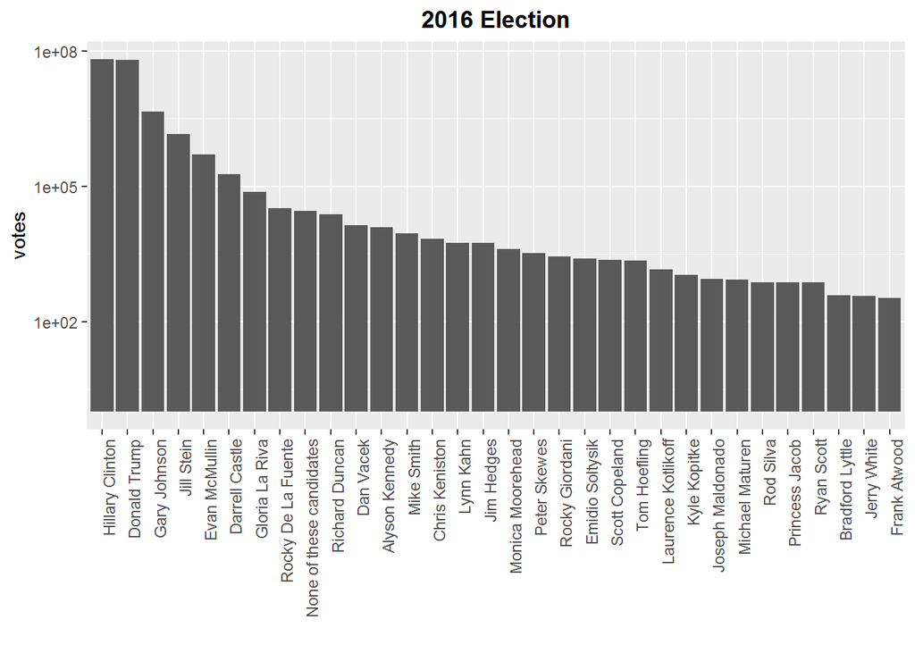

```r
his=election_federal%>%
    ggplot(data=.,aes(x=reorder(candidate,-votes),y=votes))+geom_col()+scale_y_log10()+xlab("")+ggtitle("2016 Election")+theme(axis.text.x=element_text(angle = 90, hjust = 1),plot.title=element_text(hjust=0.5,face="bold"))
his
```

```r
#    ggtitle("Chart of 2016 Election")+theme(plot.title = #element_text(hjust = 0.5))
#his
```

```r
state_winner=election_state%>%
              dplyr::group_by(state)%>%
              dplyr::mutate(total=sum(votes))%>%
              dplyr::mutate(pct=votes/total)%>%
              dplyr::top_n(1,pct)

county_winner=election%>%
              dplyr::group_by(fips)%>%
              dplyr::mutate(total=sum(votes))%>%
              dplyr::mutate(pct=votes/total)%>%
              dplyr::top_n(1,pct)
head(state_winner)
```

| county | fips | candidate | state | votes | total | pct |
| --- | --- | --- | --- | --- | --- | --- |
| NA | CA | Hillary Clinton | CA | 8753788 | 14060856 | 0.6225644 |
| NA | FL | Donald Trump | FL | 4617886 | 9419886 | 0.4902274 |
| NA | TX | Donald Trump | TX | 4685047 | 8917965 | 0.5253493 |
| NA | NY | Hillary Clinton | NY | 4556124 | 7660190 | 0.5947795 |
| NA | PA | Donald Trump | PA | 2970733 | 6115402 | 0.4857789 |
| NA | IL | Hillary Clinton | IL | 3090729 | 5523142 | 0.5595962 |

```r
head(county_winner)
```

| county | fips | candidate | state | votes | total | pct |
| --- | --- | --- | --- | --- | --- | --- |
| Los Angeles County | 6037 | Hillary Clinton | CA | 2464364 | 3421533 | 0.7202514 |
| Cook County | 17031 | Hillary Clinton | IL | 1611946 | 2156395 | 0.7475189 |
| Maricopa County | 4013 | Donald Trump | AZ | 747361 | 1536743 | 0.4863279 |
| Harris County | 48201 | Hillary Clinton | TX | 707914 | 1305434 | 0.5422825 |
| San Diego County | 6073 | Hillary Clinton | CA | 735476 | 1291078 | 0.5696604 |
| Orange County | 6059 | Hillary Clinton | CA | 609961 | 1186203 | 0.5142130 |

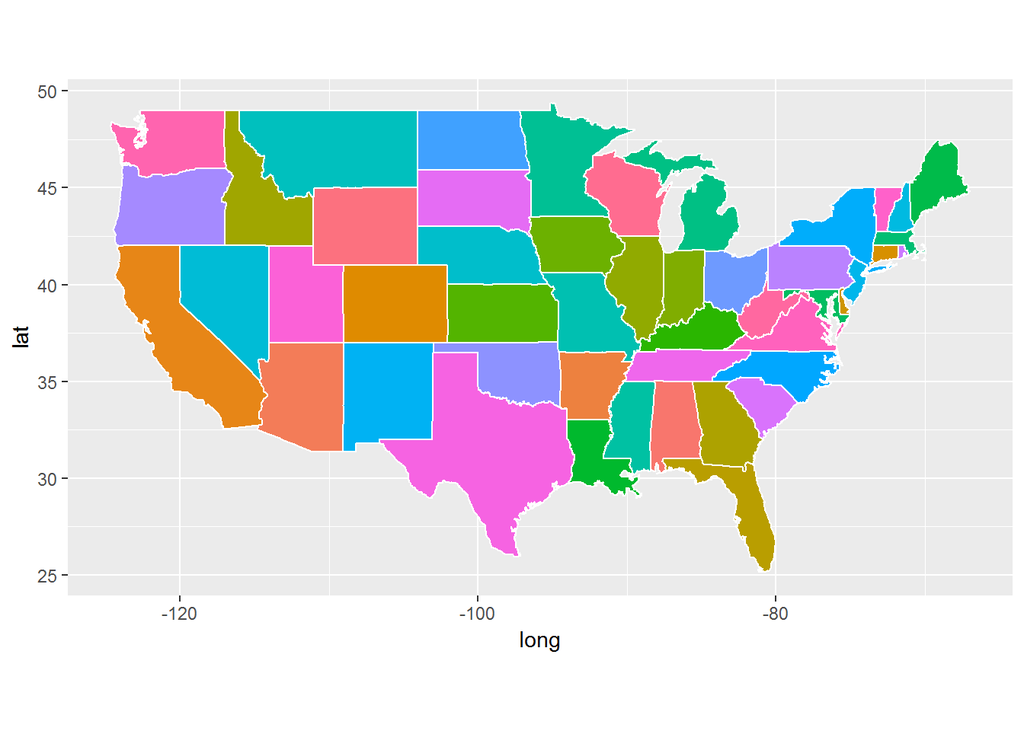

```r
states = map_data("state")
ggplot(data = states) +
geom_polygon(aes(x = long, y = lat, fill = region, group = group), color = "white") +
coord_fixed(1.3) +
guides(fill=FALSE) # color legend is unnecessary and takes too long
```

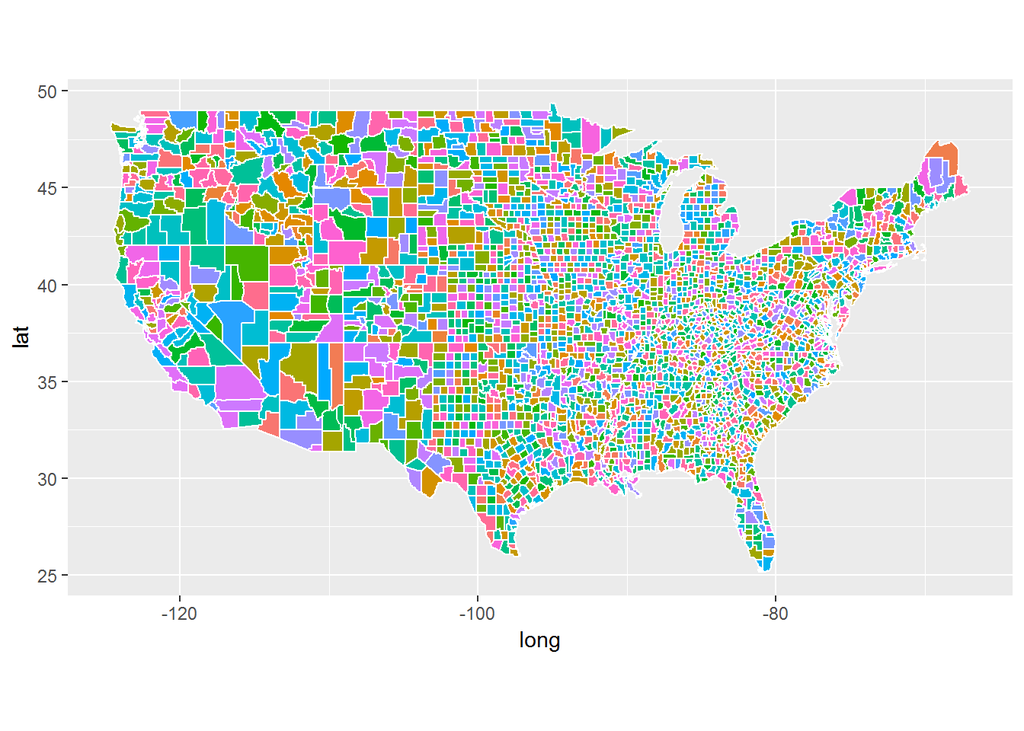

```r
counties = map_data("county")
ggplot(data = counties) +
geom_polygon(aes(x = long, y = lat, fill = subregion, group = group), color = "white") +
coord_fixed(1.3) +
guides(fill=FALSE)
```

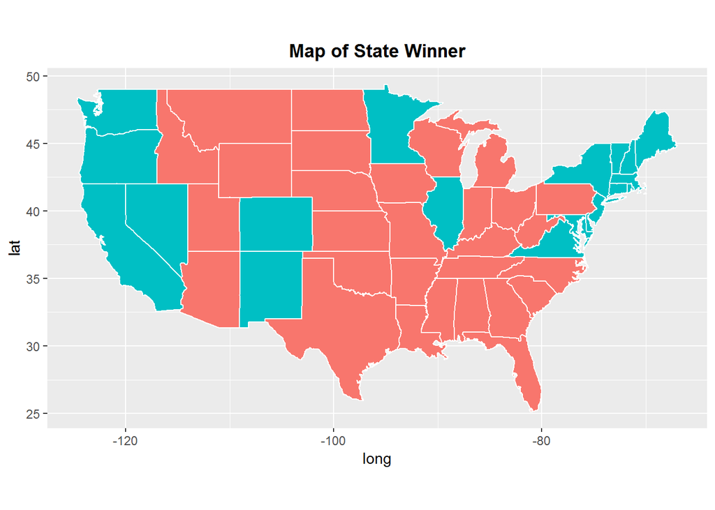

```r
states = map_data("state")
states=states%>%mutate(fips=state.abb[match(region,tolower(state.name))])%>%left_join(state_winner)
#state_winner$state=as.character(state_winner$state)
#states=left_join(states,state_winner,by=c("fips"="state"))
ggplot(data = states) +
geom_polygon(aes(x = long, y = lat, fill = candidate, group = group), color = "white") +
coord_fixed(1.3) +ggtitle("Map of State Winner")+theme(plot.title=element_text(hjust=0.5,face="bold"))+
guides(fill=FALSE) # color legend is unnecessary and takes too long
```

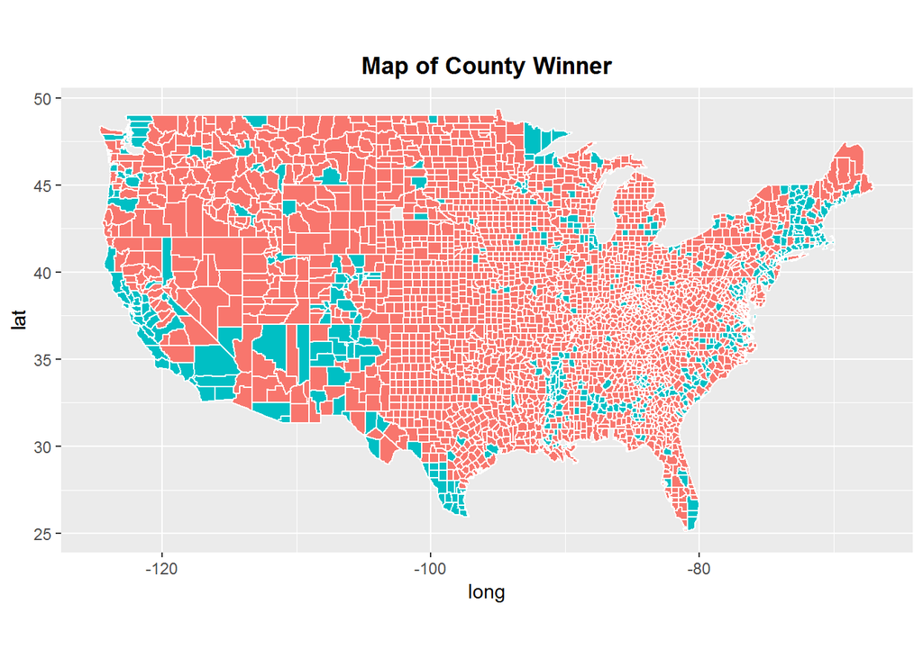

```r
county.fips=county.fips%>%separate(col="polyname",c("state","county"),sep=",")
counties=left_join(counties,county.fips,by=c("region"="state","subregion"="county"))
counties$fips=as.character(counties$fips)
county_winner$fips=as.character(county_winner$fips)
county=left_join(county_winner,counties,by=c("fips"="fips"))
ggplot(data = county) +
geom_polygon(aes(x = long, y = lat, fill = candidate, group = fips), color = "white") +
coord_fixed(1.3) +ggtitle("Map of County Winner")+theme(plot.title=element_text(hjust=0.5,face="bold"))+
guides(fill=FALSE)
```

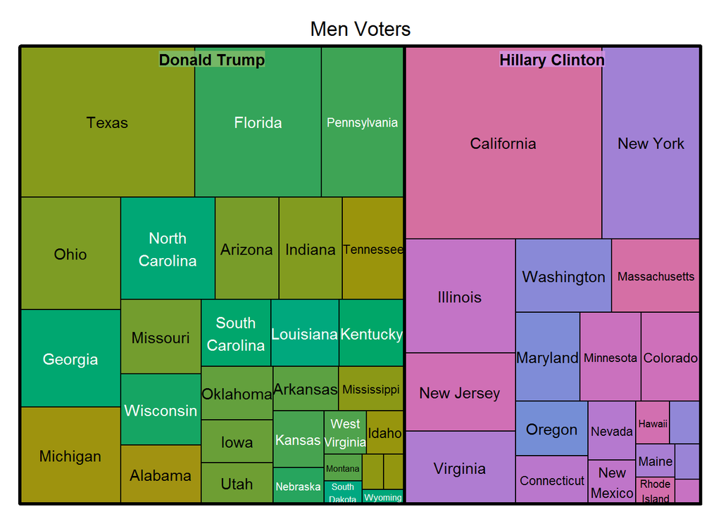

```r
census_state=census%>%na.omit()%>%mutate(state = state.abb[match(State, state.name)]) %>% left_join(state_winner)
treemap(census_state,index=c("candidate","State"),vSize="Men",type="index",title="Men Voters",ymod.label=c(2.1,0))
```

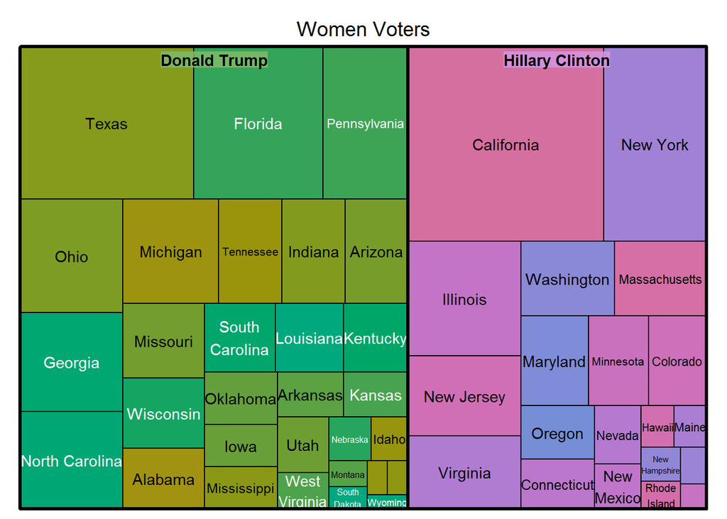

```r
treemap(census_state,index=c("candidate","State"),vSize="Women",type="index",title="Women Voters",ymod.label=c(2.1,0))
```

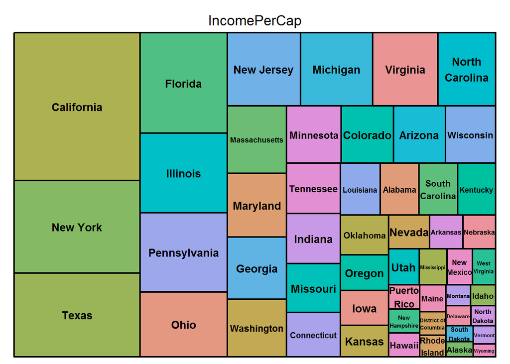

```r
treemap(census,index="State",vSize="IncomePerCap",type="index")
```

```r
census.del=census%>%
            na.omit()%>%
            dplyr::mutate(Employed=Employed*100/(Men+Women),
                    Citizen=Citizen*100/(Men+Women),
                    Men=Men*100/(Men+Women),
                    Minority=Hispanic+Black+Native+Asian+Pacific)%>%
            dplyr::select(-c("Hispanic","Black","Native","Asian","Pacific","Women","Walk","PublicWork","Construction"))

census.subct=census.del%>%
              dplyr::group_by(State,County)%>%
              add_tally(wt=TotalPop)%>%
              mutate(CountyTotal=n,Weight=TotalPop/CountyTotal)%>%
              select(-n)
census.ct=census.subct%>%
          dplyr::group_by(State,County)%>%
          dplyr::summarize_at(c(3:27),funs(round(sum(.*Weight),2)))
head(census.ct)
```

| State | County | Men | White | Citizen | Income | IncomeErr | IncomePerCap | IncomePerCapErr | Poverty | ChildPoverty | Professional | Service | Office | Production | Drive | Carpool | Transit | OtherTransp | WorkAtHome | MeanCommute | Employed | PrivateWork | SelfEmployed | FamilyWork | Unemployment | Minority |
| --- | --- | --- | --- | --- | --- | --- | --- | --- | --- | --- | --- | --- | --- | --- | --- | --- | --- | --- | --- | --- | --- | --- | --- | --- | --- | --- |
| Alabama | Autauga | 48.43 | 75.79 | 73.75 | 51696.29 | 7771.01 | 24974.50 | 3433.67 | 12.91 | 18.71 | 32.79 | 17.17 | 24.28 | 17.16 | 87.51 | 8.78 | 0.10 | 1.31 | 1.84 | 26.50 | 43.44 | 73.74 | 5.43 | 0.00 | 7.73 | 22.54 |
| Alabama | Baldwin | 48.85 | 83.10 | 75.69 | 51074.36 | 8745.05 | 27316.84 | 3803.72 | 13.42 | 19.48 | 32.73 | 17.95 | 27.10 | 11.32 | 84.60 | 8.96 | 0.13 | 1.44 | 3.85 | 26.32 | 44.05 | 81.28 | 5.91 | 0.36 | 7.59 | 15.21 |
| Alabama | Barbour | 53.83 | 46.23 | 76.91 | 32959.30 | 6031.06 | 16824.22 | 2430.19 | 26.51 | 43.56 | 26.12 | 16.46 | 23.28 | 23.32 | 83.33 | 11.06 | 0.50 | 1.62 | 1.50 | 24.52 | 31.92 | 71.59 | 7.15 | 0.09 | 17.53 | 51.94 |
| Alabama | Bibb | 53.41 | 74.50 | 77.40 | 38886.63 | 5662.36 | 18430.99 | 3073.60 | 16.60 | 27.20 | 21.59 | 17.96 | 17.47 | 23.74 | 83.43 | 13.15 | 0.50 | 1.56 | 0.73 | 28.71 | 36.69 | 76.74 | 6.64 | 0.39 | 8.16 | 24.17 |
| Alabama | Blount | 49.41 | 87.85 | 73.38 | 46237.97 | 8695.79 | 20532.27 | 2052.06 | 16.72 | 26.86 | 28.53 | 13.94 | 23.84 | 20.10 | 84.85 | 11.28 | 0.36 | 0.42 | 2.27 | 34.84 | 38.45 | 81.83 | 4.23 | 0.36 | 7.70 | 10.59 |
| Alabama | Bullock | 53.01 | 22.20 | 75.45 | 33292.69 | 9000.34 | 17579.57 | 3110.64 | 24.50 | 37.29 | 19.55 | 14.92 | 20.17 | 25.74 | 74.77 | 14.84 | 0.77 | 1.82 | 3.10 | 28.63 | 36.20 | 79.09 | 5.27 | 0.00 | 17.89 | 76.54 |

```r
ct.pc=census.ct%>%
      ungroup%>%
      dplyr::select(Men:Minority)%>%
      prcomp(scale=TRUE,center=TRUE)

subct.pc=census.subct%>%
      ungroup%>%
      dplyr::select(Men:Minority)%>% #Totalpop?
      prcomp(scale=TRUE,center=TRUE)
ct.pca=ct.pc$rotation[,1:2]
subct.pca=subct.pc$rotation[,1:2]

index_ct=order(abs(ct.pca[,1]),decreasing=TRUE)
index_subct=order(abs(subct.pca[,1]),decreasing=TRUE)
ct.pca=ct.pca[index_ct,]
subct.pca=subct.pca[index_subct,]
ct.pca
```

```
##                          PC1         PC2
## IncomePerCap     0.351554149  0.06774833
## ChildPoverty    -0.343598516 -0.05151568
## Poverty         -0.342308398 -0.07877015
## Employed         0.327837484  0.04408699
## Income           0.320033809  0.13541019
## Unemployment    -0.290698724  0.02929755
## Professional     0.250165786 -0.11120410
## Minority        -0.226531530 -0.04583274
## White            0.223026235  0.04854335
## IncomePerCapErr  0.194524378  0.03709535
## Service         -0.181802543 -0.09568071
## WorkAtHome       0.174893904 -0.37459686
## IncomeErr        0.169869206  0.14264964
## Production      -0.118759249  0.18642678
## SelfEmployed     0.097754207 -0.39843550
## Drive           -0.094144381  0.36318698
## Carpool         -0.076714956 -0.06565115
## Transit          0.070752693  0.01459493
## MeanCommute     -0.058604318  0.22788393
## PrivateWork      0.056472885  0.44667344
## FamilyWork       0.048683798 -0.27489064
## Office          -0.014999663  0.25846663
## OtherTransp     -0.009661447 -0.15281350
## Men              0.006812396 -0.16893052
## Citizen          0.004687668 -0.04178918
```

```r
subct.pca
```

```
##                         PC1          PC2
## IncomePerCap     0.31884859 -0.178244989
## Professional     0.30686496 -0.154052613
## Poverty         -0.30444951 -0.076564983
## Income           0.30250072 -0.150118580
## ChildPoverty    -0.29772431 -0.047486186
## Service         -0.26881316 -0.072117588
## Unemployment    -0.25260334 -0.088744162
## Minority        -0.24175412 -0.305499716
## White            0.24016342  0.308680193
## Employed         0.22131412 -0.039399388
## IncomePerCapErr  0.21354592 -0.218871311
## Production      -0.20705014  0.207928331
## IncomeErr        0.19977349 -0.233208031
## WorkAtHome       0.17388608 -0.119399969
## Carpool         -0.16297605  0.042373782
## Citizen          0.16133721  0.217143677
## Drive            0.07776443  0.436917687
## SelfEmployed     0.07114733 -0.042856495
## Transit         -0.05635290 -0.437751840
## OtherTransp     -0.04464935 -0.162830018
## PrivateWork     -0.04261844 -0.003276937
## Men              0.01740104  0.041612414
## FamilyWork       0.01554012  0.027351590
## Office          -0.01443059  0.084172911
## MeanCommute      0.01026841 -0.285348602
```

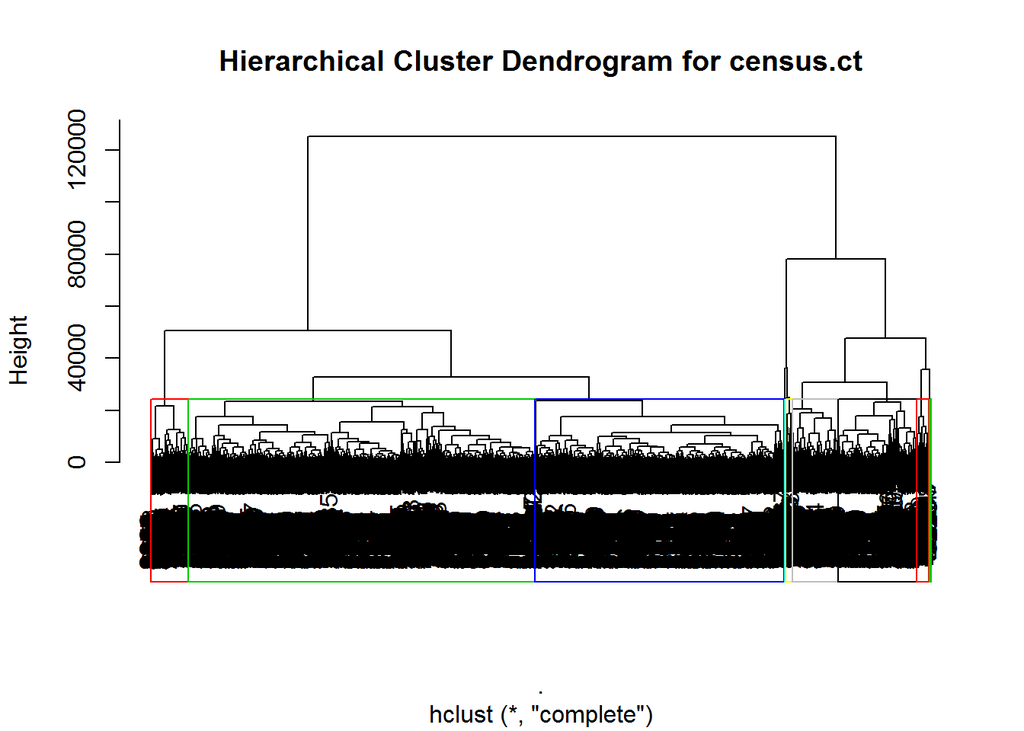

```r
ct_hc=census.ct%>%
        ungroup()%>%
        dplyr::select(-c(State,County))%>%
        dist(scale(.),method="euclidean")%>%
        hclust(method="complete")
ct.pc_hc=ct.pc$x[,1:5]%>%
        dist(scale(.),method="euclidean")%>%
        hclust(method="complete")


plot(ct_hc,main="Hierarchical Cluster Dendrogram for census.ct")
rect.hclust(ct_hc,k=10, border = 2:11)
```

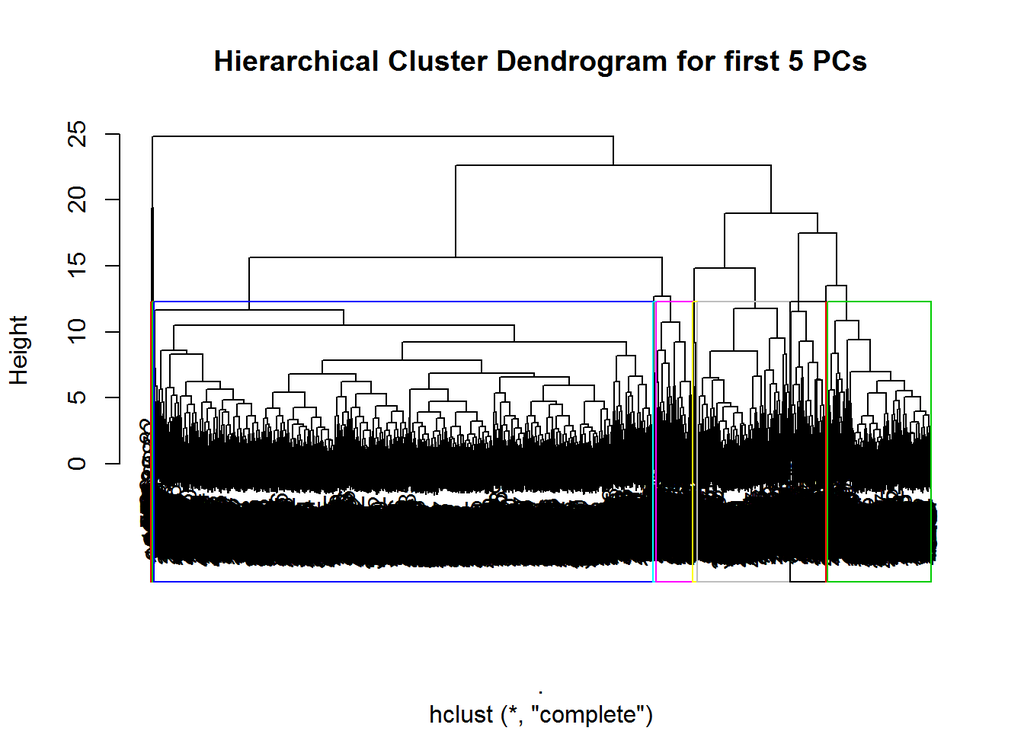

```r
ct.cut=cutree(ct_hc,k=10)

plot(ct.pc_hc,main="Hierarchical Cluster Dendrogram for first 5 PCs")
rect.hclust(ct.pc_hc,k=10, border = 2:11)
```

```r
ct.pc.cut=cutree(ct.pc_hc,10)
```

```r
index1=ct.cut[which(census.ct$County=="San Mateo")]
index2=ct.pc.cut[which(census.ct$County=="San Mateo")]
ct.M=census.ct[which(ct.cut==index1),]
ct.pc.M=census.ct[which(ct.pc.cut==index2),]
ct.M_ave=ct.M%>%ungroup%>%select(c(Men:Minority))%>%

            summarize_at(vars(Men:Minority),mean)

ct.pc.M_ave=ct.pc.M%>%ungroup%>%summarize_at(vars(Men:Minority),mean)
SanM=census.ct%>%ungroup%>%filter(County=="San Mateo")%>%select(c(Men:Minority))
compare=data.frame(rbind(SanM,ct.M_ave,ct.pc.M_ave))
row.names(compare)=c("San Mateo","Cluster Mean","PC Cluster Mean")
compare
```

|  | Men | White | Citizen | Income | IncomeErr | IncomePerCap | IncomePerCapErr | Poverty | ChildPoverty | Professional | Service | Office | Production | Drive | Carpool | Transit | OtherTransp | WorkAtHome | MeanCommute | Employed | PrivateWork | SelfEmployed | FamilyWork | Unemployment | Minority |
| --- | --- | --- | --- | --- | --- | --- | --- | --- | --- | --- | --- | --- | --- | --- | --- | --- | --- | --- | --- | --- | --- | --- | --- | --- | --- |
| San Mateo | 49.20000 | 40.64000 | 64.20000 | 100369.92 | 16123.02 | 47881.29 | 6115.550 | 8.010000 | 9.710000 | 45.74000 | 18.29000 | 22.30000 | 7.340000 | 69.93000 | 10.680000 | 9.260000 | 2.600000 | 5.080000 | 26.83000 | 51.72000 | 79.77000 | 8.370000 | 0.1700000 | 6.690000 | 55.53000 |
| Cluster Mean | 49.21115 | 67.74385 | 68.69962 | 100257.27 | 14146.49 | 45278.06 | 5544.617 | 6.651923 | 7.982308 | 49.25231 | 14.97154 | 22.71115 | 6.439231 | 74.22846 | 8.365769 | 7.783462 | 1.511154 | 5.764231 | 31.06462 | 51.38731 | 77.59154 | 5.817308 | 0.1338462 | 5.912692 | 29.80115 |
| PC Cluster Mean | 49.44953 | 73.02311 | 72.17606 | 69597.31 | 10202.79 | 32873.33 | 4209.829 | 10.953731 | 13.903264 | 38.60298 | 17.13583 | 23.98117 | 10.513057 | 78.67938 | 9.269793 | 2.910984 | 1.601658 | 4.930518 | 26.33808 | 49.29461 | 78.15329 | 6.169819 | 0.1536528 | 6.707176 | 24.64487 |

#Classification

```r
tmpwinner = county_winner %>% ungroup %>%
mutate(state = state.name[match(state, state.abb)]) %>% ## state abbreviations
mutate_at(vars(state, county), tolower) %>% ## to all lowercase
mutate(county = gsub(" county| columbia| city| parish", "", county)) ## remove suffixes
tmpcensus = census.ct %>%ungroup%>% mutate_at(vars(State, County), tolower)
election.cl = tmpwinner %>%
left_join(tmpcensus, by = c("state"="State", "county"="County")) %>%
na.omit
## saves meta information to attributes
attr(election.cl, "location") = election.cl %>% select(c(county, fips, state, votes, pct))
election.cl = election.cl %>% select(-c(county, fips, state, votes, pct))
```

```r
set.seed(10)
n = nrow(election.cl)
in.trn= sample.int(n, 0.8*n)
trn.cl = election.cl[ in.trn,]
tst.cl = election.cl[-in.trn,]
```

```r
set.seed(20)
nfold = 10
folds = sample(cut(1:nrow(trn.cl), breaks=nfold, labels=FALSE))


calc_error_rate = function(predicted.value, true.value){
return(mean(true.value!=predicted.value))
}
records = matrix(NA, nrow=3, ncol=2)
colnames(records) = c("train.error","test.error")
rownames(records) = c("tree","knn","lda")
```

```r
XTrain=trn.cl%>%select(-candidate)
YTrain=trn.cl$candidate
XTest=tst.cl%>%select(-candidate)
YTest=tst.cl$candidate
```

```r
do.chunk <- function(chunkid, folddef, Xdat, Ydat, k){
train = (folddef!=chunkid)
Xtr = Xdat[train,]
Ytr = Ydat[train]
Xvl = Xdat[!train,]
Yvl = Ydat[!train]
## get classifications for current training chunks
predYtr = knn(train = Xtr, test = Xtr, cl = Ytr, k = k)
## get classifications for current test chunk
predYvl = knn(train = Xtr, test = Xvl, cl = Ytr, k = k)
data.frame(train.error = calc_error_rate(predYtr, Ytr),
val.error = calc_error_rate(predYvl, Yvl))
}
```

```r
#setup=tree.control(nobs=nrow(trn.cl),minsize=5,mindev=1e-5)
tree.cl=tree(candidate~.,data=trn.cl)
summary(tree.cl)
```

```
##
## Classification tree:
## tree(formula = candidate ~ ., data = trn.cl)
## Variables actually used in tree construction:
## [1] "Transit"      "White"        "Unemployment" "Citizen"
## [5] "Professional" "Drive"        "Employed"     "Production"
## [9] "total"
## Number of terminal nodes:  15
## Residual mean deviance:  0.3191 = 778.8 / 2441
## Misclassification error rate: 0.05741 = 141 / 2456
```

```r
treecv=cv.tree(tree.cl,K=nfold,rand=folds,method="misclass")
tree.cl_size=min(treecv$size[treecv$dev==min(treecv$dev)])
tree.cl_pruned=prune.tree(tree.cl,best=tree.cl_size,method="misclass")
pred.train=predict(tree.cl_pruned,trn.cl,type="class")
pred.test=predict(tree.cl_pruned,tst.cl,type="class")
train.err1=calc_error_rate(pred.train,YTrain)
test.err1=calc_error_rate(pred.test,YTest)
records[1,]=c(train.err1,test.err1)
records
```

```
##      train.error test.error
## tree  0.06107492 0.07003257
## knn           NA         NA
## lda           NA         NA
```

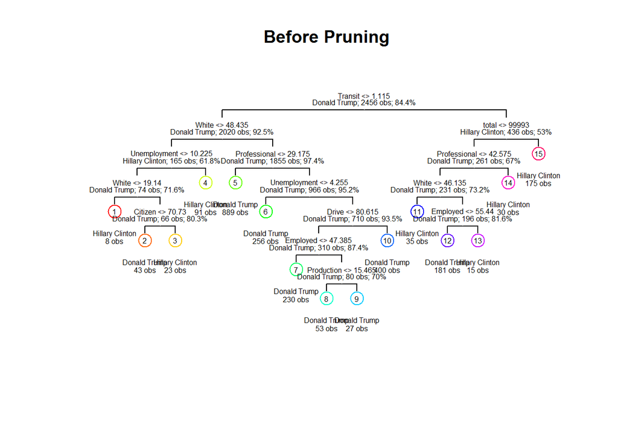

```r
draw.tree(tree.cl,nodeinfo=TRUE,cex=0.5,size=2,digits=2)
title("Before Pruning")
```

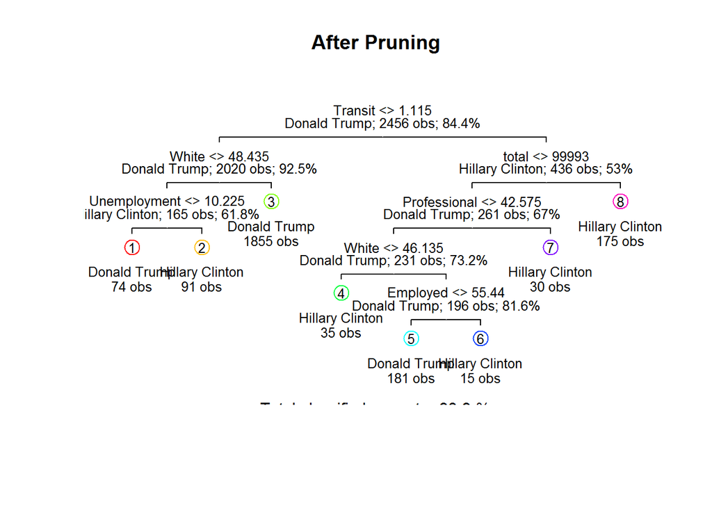

```r
draw.tree(tree.cl_pruned,nodeinfo=TRUE,cex=0.8,size=2,digits=2)
title("After Pruning")
```

```r
summary(tree.cl_pruned)
```

```
##
## Classification tree:
## snip.tree(tree = tree.cl, nodes = c(5L, 8L))
## Variables actually used in tree construction:
## [1] "Transit"      "White"        "Unemployment" "total"
## [5] "Professional" "Employed"
## Number of terminal nodes:  8
## Residual mean deviance:  0.402 = 984 / 2448
## Misclassification error rate: 0.06107 = 150 / 2456
```

```r
kv=c(1, seq(5, 50, length.out=10))
error.folds=NULL
for (j in kv){
tmp = ldply(1:nfold, do.chunk, folddef=folds, Xdat=XTrain,Ydat=YTrain,k = j)
error.folds = rbind(error.folds, tmp)
}

num=c(rep(0:10,each=10))
df=cbind(num,error.folds)
colnames(df)=c("N","train.error","test.error")
average=df%>%
    group_by(N) %>%
    summarise_at(.funs=funs(mean),.var=vars(train.error,test.error))
best_n=min(average$N[average$test.error==min(average$test.error)])
knn_pred_train=knn(train=XTrain,test=XTrain,cl=YTrain,k=best_n)
knn_pred_test=knn(train=XTrain,test=XTest,cl=YTrain,k=best_n)
train.err2=calc_error_rate(knn_pred_train,YTrain)
test.err2=calc_error_rate(knn_pred_test,YTest)
records[2,]=c(train.err2,test.err2)
records
```

```
##      train.error test.error
## tree  0.06107492 0.07003257
## knn   0.08265472 0.14820847
## lda           NA         NA
```

```r
pca.records = matrix(NA, nrow=3, ncol=2)
colnames(pca.records) = c("train.error","test.error")
rownames(pca.records) = c("tree","knn","lda")
```

```r
trn.pca=trn.cl%>%
        dplyr::select(Men:Minority)%>%
        prcomp(scale=TRUE,center=TRUE)
#names(trn.pca)
#trn.pca$rotation
#dim(trn.pca$x)
trn.dev=trn.pca$sdev
trn_pve=trn.dev^2/sum(trn.dev^2)
trn_cumu_pve=cumsum(trn_pve)
min.trn.pc=min(which(trn_cumu_pve > 0.9))
print(min.trn.pc)
```

```
## [1] 13
```

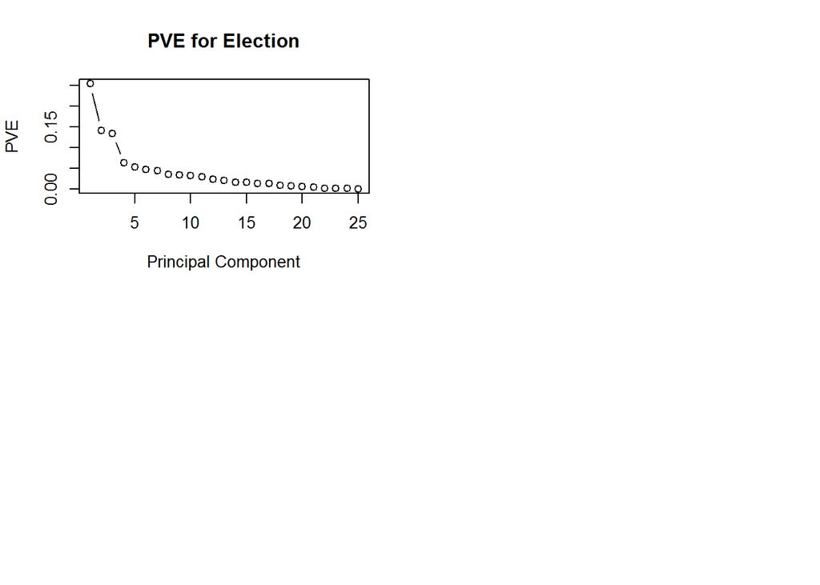

```r
par(mfrow=c(2, 2))
plot(trn_pve,xlab = "Principal Component",ylab = "PVE",main="PVE for Election",type="b")
#plot(ele_cumu_pve, type="l", lwd=3,
#     xlab = "Principal Component",
#     ylab = "Cumulative PVE",ylim = c(0,1),main="Cumulative PVE for county data")
```

```r
tr.pca=data.frame(candidate=trn.cl$candidate,trn.pca$x)
test.pca=tst.cl%>%
        dplyr::select(Men:Minority)%>%
        prcomp(scale=TRUE,center=TRUE)
test.pca=data.frame(candidate=tst.cl$candidate,test.pca$x)
tr.pca=tr.pca%>%
        dplyr::rename(Men=PC1,White=PC2,Citizen=PC3,Income=PC4,
              IncomeErr=PC5,IncomePerCap=PC6,IncomePerCapErr=PC7,
              Poverty=PC8,ChildPoverty=PC9,Professional=PC10,
              Service=PC11,Office=PC12,Production=PC13,Drive=PC14,
              Carpool=PC15,Transit=PC16,OtherTransp=PC17,
              WorkAtHome=PC18,MeanCommute=PC19,Employed=PC20,
              PrivateWork=PC21,SelfEmployed=PC22,FamilyWork=PC23,
              Unemployment=PC24,Minority=PC25)
test.pca=test.pca%>%
              dplyr::rename(Men=PC1,White=PC2,Citizen=PC3,Income=PC4,
              IncomeErr=PC5,IncomePerCap=PC6,IncomePerCapErr=PC7,
              Poverty=PC8,ChildPoverty=PC9,Professional=PC10,
              Service=PC11,Office=PC12,Production=PC13,Drive=PC14,
              Carpool=PC15,Transit=PC16,OtherTransp=PC17,
              WorkAtHome=PC18,MeanCommute=PC19,Employed=PC20,
              PrivateWork=PC21,SelfEmployed=PC22,FamilyWork=PC23,
              Unemployment=PC24,Minority=PC25)
```

```r
tre.trn.pca=tree(candidate~.,data=tr.pca)
summary(tre.trn.pca)
```

```
##
## Classification tree:
## tree(formula = candidate ~ ., data = tr.pca)
## Variables actually used in tree construction:
## [1] "Citizen"      "Drive"        "OtherTransp"  "White"
## [5] "Poverty"      "PrivateWork"  "Men"          "IncomePerCap"
## Number of terminal nodes:  17
## Residual mean deviance:  0.4358 = 1063 / 2439
## Misclassification error rate: 0.07695 = 189 / 2456
```

```r
trecv.pca=cv.tree(tre.trn.pca,K=nfold,rand=folds,method="misclass")
tre.cl.pca_size=min(trecv.pca$size[trecv.pca$dev==min(trecv.pca$dev)])
tre.cl.pca_pruned=prune.tree(tre.trn.pca,
                            best=tre.cl.pca_size,method="misclass")
tre_pca.pred.train=predict(tre.cl.pca_pruned,tr.pca,type="class")
tre_pca.pred.test=predict(tre.cl.pca_pruned,test.pca,type="class")
train.cpa.err1=calc_error_rate(tre_pca.pred.train,YTrain)
test.cpa.err1=calc_error_rate(tre_pca.pred.test,YTest)
pca.records[1,]=c(train.err1,test.err1)
pca.records
```

```
##      train.error test.error
## tree  0.06107492 0.07003257
## knn           NA         NA
## lda           NA         NA
```

```r
XTrain.pca=tr.pca%>%select(-candidate)
YTrain.pca=tr.pca$candidate
XTest.pca=test.pca%>%select(-candidate)
YTest.ca=test.pca$candidate
```

```r
kv=c(1, seq(5, 50, length.out=10))
error.folds=NULL
for (j in kv)
{
  tmp=ldply(1:nfold,do.chunk, folddef=folds, Xdat=XTrain.pca,
                              Ydat=YTrain.pca,k = j)
  error.folds = rbind(error.folds, tmp)
}

num=c(rep(0:10,each=10))
df.pca=cbind(num,error.folds)
colnames(df.pca)=c("N","train.error","test.error")
ave.pca=df.pca%>%
    group_by(N) %>%
    summarise_at(.funs=funs(mean),.var=vars(train.error,test.error))
best_n.pca=min(ave.pca$N[ave.pca$test.error==min(ave.pca$test.error)])
knn_pred_tr.pca=knn(train=XTrain.pca,test=XTrain.pca,
                    cl=YTrain.pca,k=best_n.pca)
knn_pred_tst.pca=knn(train=XTrain.pca,test=XTest.pca,
                    cl=YTrain.pca,k=best_n.pca)
train.pca.err2=calc_error_rate(knn_pred_train,YTrain)
test.pca.err2=calc_error_rate(knn_pred_test,YTest)
pca.records[2,]=c(train.pca.err2,test.pca.err2)
pca.records
```

```
##      train.error test.error
## tree  0.06107492 0.07003257
## knn   0.08265472 0.14820847
## lda           NA         NA
```

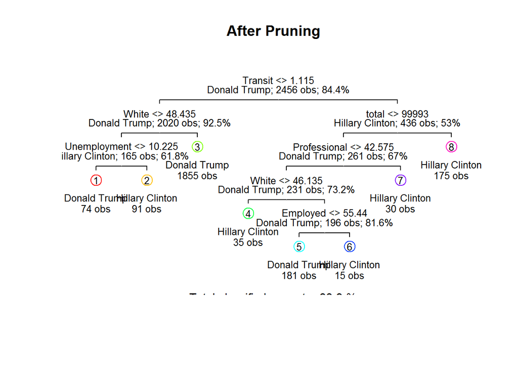

```r
draw.tree(tree.cl_pruned,nodeinfo=TRUE,cex=0.8,size=2,digits=2)
title("After Pruning")
```

```r
#ROC of Tree
predict_tree=predict(tree.cl_pruned,XTest,type="vector")[,13]
pred_tree=prediction(predict_tree,droplevels(YTest))
perf_tree=performance(pred_tree,measure="tpr",x.measure="fpr")
auc_tree=performance(pred_tree,measure="auc")
```

```r
#ROC of log
glm.fit=glm(candidate~., data =trn.cl,family=binomial("logit"))
fitted_values<-predict(glm.fit, newdata=XTest, type="response")
pred_log=prediction(fitted_values,droplevels(YTest))
perf_log=performance(pred_log,measure="tpr",x.measure="fpr")
auc_log=performance(pred_log,measure="auc")
```

```r
#install.packages("randomForest")
library(randomForest)
```

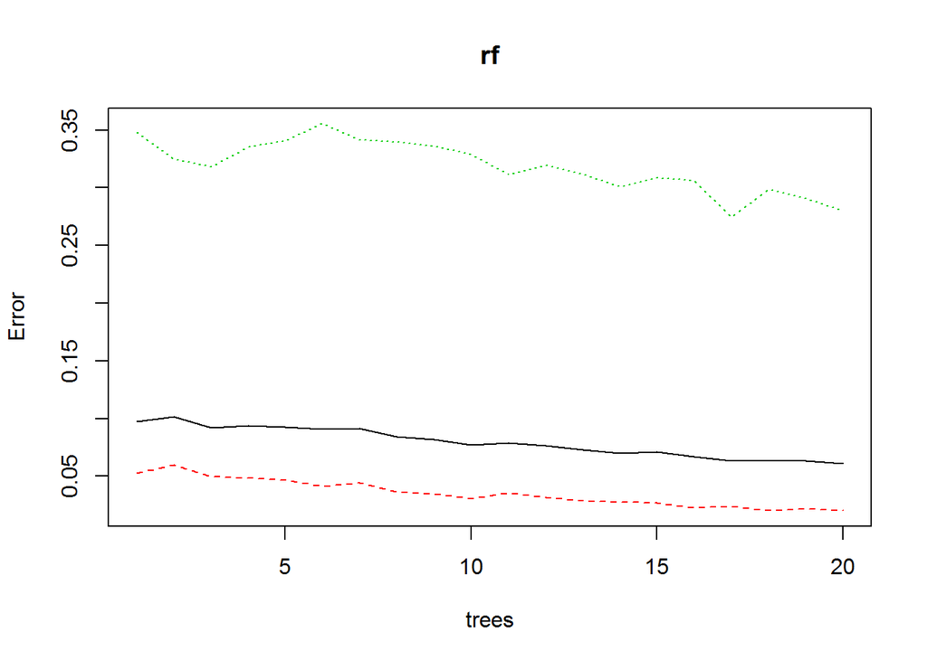

```r
#bagging
#bag.election <- randomForest(candidate ~ ., data=trn.cl, mtry=23, importance=TRUE)
rf=randomForest(candidate~.,data=droplevels(trn.cl), mtry=sqrt(33),ntre=20, importance=TRUE)
plot(rf)
```

```r
print(rf)
```

```
##
## Call:
##  randomForest(formula = candidate ~ ., data = droplevels(trn.cl),      mtry = sqrt(33), ntre = 20, importance = TRUE)
##                Type of random forest: classification
##                      Number of trees: 20
## No. of variables tried at each split: 6
##
##         OOB estimate of  error rate: 6.07%
## Confusion matrix:
##                 Donald Trump Hillary Clinton class.error
## Donald Trump            2032              42  0.02025072
## Hillary Clinton          107             275  0.28010471
```

```r
train_rf=predict(rf, XTrain,type="response")
#confusionMatrix(train_rf,YTrain)
trn.rf.err=table(pred=train_rf,truth=YTrain)
trn.rf.err=trn.rf.err[,c(7,13)]
train.rf.err = 1-sum(diag(trn.rf.err))/sum(trn.rf.err)
rf.test=predict(rf,newdata=XTest)
tst.rf.err=table(pred=rf.test,truth=YTest)
tst.rf.err=tst.rf.err[,c(7,13)]
test.rf.err= 1-sum(diag(tst.rf.err))/sum(tst.rf.err)
train.rf.err
```

```
## [1] 0.002035831
```

```r
test.rf.err
```

```
## [1] 0.05211726
```

```r
#ROC of random forest
rf_pred=predict(rf,newdata = XTest,type="vote")[,2]
pred_rf<-prediction(rf_pred,droplevels(YTest))
perf_rf<-performance(pred_rf,measure="tpr",x.measure="fpr")
auc_rf<-performance(pred_rf,measure="auc")
```

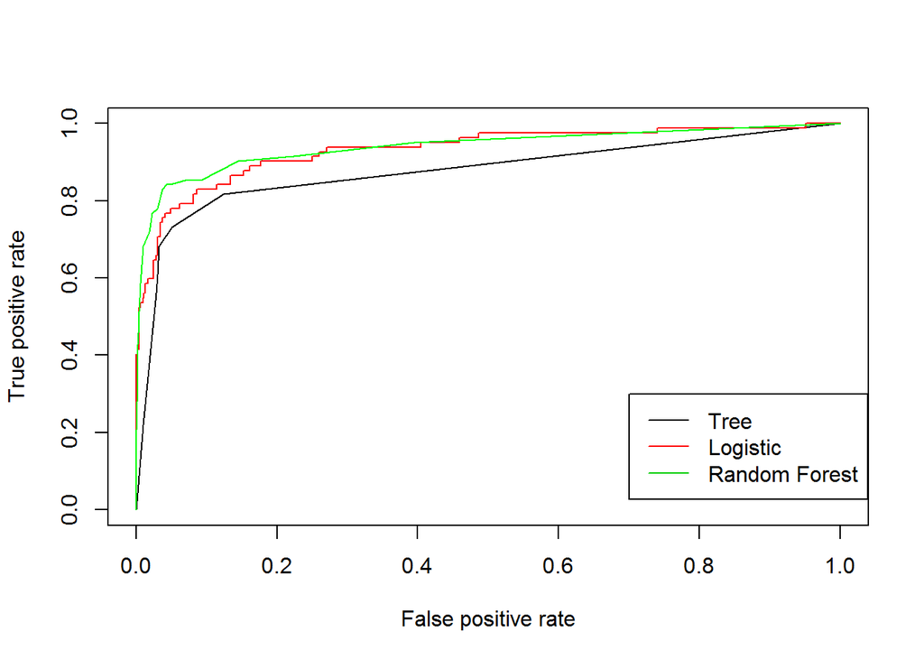

```r
#Plot ROC
plot(perf_tree)
plot(perf_log,col="red",add=TRUE)
plot(perf_rf,col="green",add=TRUE)
legend(0.7,0.3,col=c(1,2,3),legen=c("Tree","Logistic","Random Forest"),lty=1,lwd=c(1,1,1))
```

```r
auc=matrix(NA, nrow=3, ncol=1)
colnames(auc) = c("AUC")
rownames(auc) = c("tree","logistic","random forest")
auc[1,]=round(auc_tree@y.values[[1]],3)
auc[2,]=round(auc_log@y.values[[1]],3)
auc[3,]=round(auc_rf@y.values[[1]],3)
auc
```

```
##                 AUC
## tree          0.877
## logistic      0.932
## random forest 0.940
```

From the graph and chart above, we see that because random forest has the highest AUC and the lowest testing error for predicting votes, random forest is a better preidction model for 2016 election.

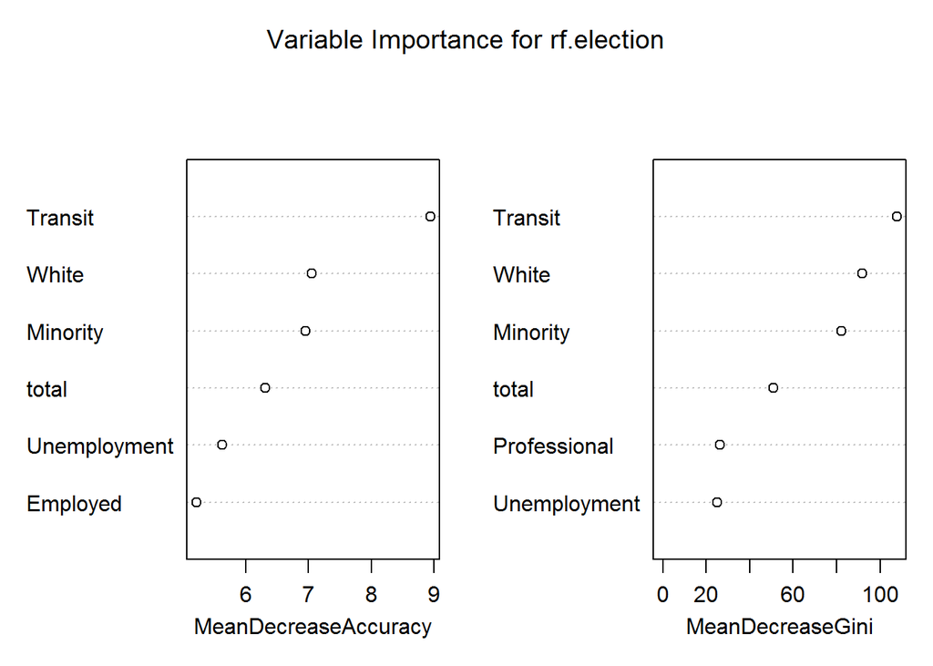